# Numerator Data Science Challenge

### Christopher Ivanovich, Data Scientist @ Linkbal Japan

### The Scenario:

You have been tasked by the Product team to develop a new type of analysis that can predict buyer behavior based on historical purchase activity. They want to create a simple model that can predict where shoppers are likely to visit, given a set of input variables. The outcome they would like to predict is the Retailer or set of Retailers where a shopper is most likely going to shop. The input variables can be any of the provided variables and / or any other derived features that explain the likelihood of retailer visits.

The model should be used to answer the following questions:

1. Are there any additional input variables we could provide to improve your model? What are they, and why?
2. What are the most/least important features that explain the likelihood of retailer visits?
3. For Hispanic Walmart shoppers, which other retailers are they most likely to shop at?
4. Among Dollar General shoppers, which shopper group(s) are most likely to visit, and how do they look different than other shopper group(s)?
5. How would Safeway shoppers and/or other retailers be impacted if Safeway were to close their stores?

## Getting set up, loading data

```python
import numpy as np
import pandas as pd
import matplotlib.pyplot as plt
import seaborn as sns
import sys

from sklearn.ensemble import RandomForestClassifier
from sklearn.model_selection import train_test_split
from sklearn.metrics import accuracy_score, confusion_matrix, precision_score, recall_score
from sklearn.utils.class_weight import compute_sample_weight

pd.options.display.max_columns = 250
np.set_printoptions(threshold=sys.maxsize)
```

```python
data = pd.read_csv("data.csv")
```

```python
data.drop_duplicates(inplace = True)
```

```python
data.sort_values(by =["user_id", "basket_id"], inplace = True)
```

## Initial EDA

### Dealing with missing or bad data

It was seen early on that the data contain some unstandardized null values, as well as large sections of white space in some fields. We handle those first.

As an example:

```python
data.store_geo_latitude.iloc[79347]
```

```
'                    '
```

To deal with this frequent issue, we remove all bounding white space from all object columns.

We then replace these and other missing data values with numpy NaN objects.

This is done for compatibility with Pandas data types, allowing some columns to be recognized as appropriately numeric.

```python
cat_vars = [colname for colname, dtype in zip(data.dtypes.index, data.dtypes.values) if dtype == 'object']

for obj_col in cat_vars:
    data[obj_col] = data[obj_col].str.strip()

data = data.replace(to_replace=['', 'unknown', 'TBD'], value = np.nan)
```

#### And now we can observe that a good number of our columns contain missing values:

```python
data.columns[data.isnull().mean() > 0.0]
```

```
Index(['user_geo_census_region', 'user_geo_census_division',
       'store_geo_store_name', 'store_geo_latitude', 'store_geo_longitude',
       'store_geo_state', 'store_geo_city', 'payment_method', 'salestax',
       'payment_id', 'last_update', 'user_demo_ethnicity', 'user_demo_age',
       'user_demo_education', 'user_demo_employment', 'user_demo_gender',
       'user_demo_has_children_under17', 'user_demo_household_size',
       'user_demo_income', 'user_demo_marital_status', 'trip_rating',
       'kids_present_on_trip', 'adult_genders_on_trip'],
      dtype='object')
```

### Dropping columns missing more than 50% of their data.

There is no hard rule here on what line to draw for missing data, but a look at the distribution of missing data showed us that few columns are missing more than 50%, and those columns can most likely be done without.

```python
data.columns[data.isnull().mean() > 0.5]
```

```
Index(['store_geo_store_name', 'store_geo_latitude', 'store_geo_longitude',
       'store_geo_state', 'store_geo_city', 'payment_id', 'last_update',
       'user_demo_employment'],
      dtype='object')
```

Geographical data are also encoded as city, state, etc., so we can likely do without the above `geo` fields.

Payment_id is not essential as we have basket_id and user_id (though these won't be needed for a model that needs to predict on de-personalized data).

Employment is likely an important feature, but sadly, it is entirely unknown.

```python
for col, val in zip(data.columns, data.isnull().mean()):
    if val > 0.5:
        data.drop(col, axis = 1, inplace = True)
```

## Burning question: how many distinct retailers in our data set? How many should be predict for?

```python
data.retailer_name.nunique()
```

```
1205
```

With some 1200+ retailers in the dataset, we subset on transactions for retailers with at least 500 records. This will greatly aid our task, given that it also will drastically reduce imbalance at prediction time.

If I had more time to work on this, or if it were necessary for the product, I would (and this would still be possible at a later stage of development) make use of over/under-sampling techniques or create synthentic data for the under-represented classes (SMOTE) based on the need to extend the model to these less well-represented retailers.

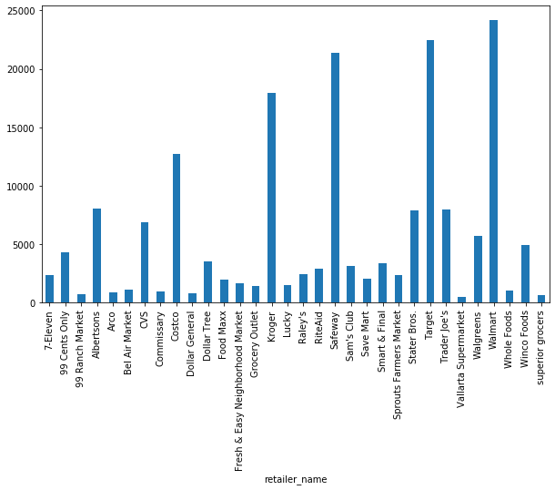

```python
counts = data.groupby('retailer_name').basket_id.count()
counts[counts > 500].plot(kind = 'bar', figsize=(10, 6))
```

### Recasting or creating dummy variables for our many categorical columns

```python
data.dtypes[data.dtypes == 'object'].index
```

```
Index(['banner_name', 'retailer_name', 'channel_name', 'parent_channel_name',
       'user_geo_city', 'user_geo_rural_code', 'user_geo_state',
       'user_geo_census_region', 'user_geo_census_division', 'payment_method',
       'trip_type', 'salestax', 'transcribed', 'user_demo_ethnicity',
       'user_demo_age', 'user_demo_education', 'user_demo_gender',
       'user_demo_has_children_under17', 'user_demo_household_size',
       'user_demo_income', 'user_demo_marital_status', 'trip_rating',
       'kids_present_on_trip', 'adult_genders_on_trip',
       'other_banners_in_shopping_trip', 'other_retailers_in_shopping_trip',
       'were_there_other_stores_on_this_shopping_trip',
       'location_during_the_shopping_trip'],
      dtype='object')
```

Some of these object columns we expect to be numerical or, if binary in nature, boolean. `transcribed`, for instance, can conveniently be recast from text to a column of 0s and 1s. In the particular case of `salestax`, while its values are numerical in nature, they are discretely distributed (with only a few distinct values), though in principle it could be continuous. Treating it as numerical will save us the need to one-hot encode it.

Those columns containing only a relatively small number of distinct, textual values can be one-hot encoded or converted to categorical columns with ordinality (e.g. red:1 , blue:2, orange:3). I elect to use one-hot encoding, which isn't strictly necessary for the model we will be using (random forest, perfect for a first sweep on a classification task). In some cases, one-hot encoding might degrade performance, but doing so will aid interpretability of the feature importances (clarifying the importance of having children versus not having children on the trip, for example). And, given the large amount of missing values for some columns, treating missing data as a yes or no question may help us highlight the importance of more thorough data collection for a particular feature.

Finally, processing the data in this way (with one-hot encoding) could save us the trouble of doing it later when we would evaluate different models for which it is required or preferred (like sequential neural networks and xgboost).

```python
(data[data.dtypes[data.dtypes == 'object'].index].nunique() <= 50).index
```

```
Index(['banner_name', 'retailer_name', 'channel_name', 'parent_channel_name',
       'user_geo_city', 'user_geo_rural_code', 'user_geo_state',
       'user_geo_census_region', 'user_geo_census_division', 'payment_method',
       'trip_type', 'salestax', 'transcribed', 'user_demo_ethnicity',
       'user_demo_age', 'user_demo_education', 'user_demo_gender',
       'user_demo_has_children_under17', 'user_demo_household_size',
       'user_demo_income', 'user_demo_marital_status', 'trip_rating',
       'kids_present_on_trip', 'adult_genders_on_trip',
       'other_banners_in_shopping_trip', 'other_retailers_in_shopping_trip',
       'were_there_other_stores_on_this_shopping_trip',
       'location_during_the_shopping_trip'],
      dtype='object')
```

```python
display(data.transcribed.unique())
data.transcribed.replace(to_replace = ['t', 'f'], value = [1, 0], inplace = True)
```

```
array(['t', 'f'], dtype=object)
```

```python
display(data.user_demo_gender.unique())
data.user_demo_gender.replace(['Female', 'Male'], [0, 1], inplace = True) #just following convention here
```

```
array(['Female', 'Male', nan], dtype=object)
```

#### And a few more columns ripe for recasting

```python
data.were_there_other_stores_on_this_shopping_trip.replace(['Multi-stop', 'Single-stop'], [1, 0], inplace = True)
```

```python
data.user_demo_has_children_under17.replace(['Yes', 'No'], [1, 0], inplace = True)
```

```python
data.trip_rating = data.trip_rating.astype(np.float64)
data.salestax = data.salestax.astype(np.float64)
```

```python
data_tmp = data.copy()
```

```python
### < 52 unique values is arbitrary, but it matches the number of US states/territories in the entire data set,
### and is a reasonable cut off point
for col, nuniq, dtype in zip(data.columns, data.nunique(), data.dtypes):
    if dtype == 'object' and nuniq < 52 and \
    col not in [
        'banner_name',
        'retailer_name',
        'channel_name',
        'parent_channel_name',
        'parent_channel_name',
        'sales_tax' #numerical,
    ]:
        temp = pd.get_dummies(data[col], drop_first = False, dummy_na = True, prefix = col)
        data_tmp = pd.concat([data_tmp, temp], axis = 1)
        data_tmp.drop(col, axis = 1, inplace = True)
```

### Dropping columns that may help the model cheat, and non-essentials

When we say cheat, we mean that a particular feature might answer the question of which records (rows) occur at which retailer, in a way that will not allow us to generalize our model to new data very well. `user_id` is a prime example, because it may be that particularly users only ever shop at a single retailer. Including it could lead the model to rely heavily on this one feature, which in many cases may answer the question by itself, and underestimate the importance of all of our other features, which are the ones we actually need to predict on unseen data. And, if the model could predict very well on the basis of `user_id`, what would happen if we provided it a never-before-seen `user_id`?

```python
to_drop = [
    'user_id',
    'basket_id',
    'banner_name',
    'banner_name',
    'channel_name',
    'parent_channel_name',
    'other_banners_in_shopping_trip',
    'other_retailers_in_shopping_trip'
]

data_tmp.drop(labels = to_drop, axis = 1, inplace = True)
```

```python
data_tmp.fillna(value = 0, axis = 1, inplace = True)
```

```python
set(data_tmp.dtypes)
```

```
{dtype('uint8'), dtype('int64'), dtype('float64'), dtype('O')}
```

### How to handle city?

We will attempt to employ a tree-based method, which is tolerant of unscaled and even purely ordinal numerical data, so, we will encode it as such, and keep the names around for later if needed for interpretation.

```python
cities = data_tmp.user_geo_city
data_tmp.user_geo_city = data_tmp.user_geo_city.astype('category').cat.codes
```

```python
data_tmp.retailer_name = data_tmp.retailer_name.astype('category')
```

```python
retailer_codes = {i: name for i, name in zip(range(len(data_tmp.retailer_name.cat.categories)), data_tmp.retailer_name.cat.categories)}
```

### Separating between predictor and objective columns, and preparing our model

```python
Y = data_tmp.retailer_name.cat.codes
X = data_tmp.drop(['retailer_name'], axis = 1).copy()
```

```python
rfc = RandomForestClassifier(
    n_estimators=100,
    criterion='gini',
    max_depth=None,
    min_samples_split=2,
    min_samples_leaf=1,
    min_weight_fraction_leaf=0.0,
    max_features='auto',
    max_leaf_nodes=None,
    min_impurity_decrease=0.0,
    min_impurity_split=None,
    bootstrap=True,
    oob_score=False,
    n_jobs=None,
    random_state=None,
    verbose=0,
    warm_start=False,
    class_weight=None,
    ccp_alpha=0.0,
    max_samples=None,
)
```

### Train and test time!

```python
X_train, X_test, y_train, y_test = train_test_split(X, Y, test_size = 0.33, shuffle = True)
```

```python
rfc.fit(
    X_train,
    y_train,
    sample_weight = compute_sample_weight("balanced", y_train)
)
```

```
RandomForestClassifier(bootstrap=True, ccp_alpha=0.0, class_weight=None,
                       criterion='gini', max_depth=None, max_features='auto',
                       max_leaf_nodes=None, max_samples=None,
                       min_impurity_decrease=0.0, min_impurity_split=None,
                       min_samples_leaf=1, min_samples_split=2,
                       min_weight_fraction_leaf=0.0, n_estimators=100,
                       n_jobs=None, oob_score=False, random_state=None,
                       verbose=0, warm_start=False)
```

**Note** the importance of `compute_sample_weight`; it is key to assign weights based on the proporition of entries for each retailer. To do otherwise would utterly obscure the less well-represented retailers in the model.

```python
pred = rfc.predict(X_test)
```

## Questions

### 1. Are there any additional input variables we could provide to improve your model? What are they, and why?

As we see below, location is an extremely important feature, which is pretty intuitive: when a shopper determines which store they will be visiting, probably the largest concern is physical accessibility, and these shopping trips are almost all undertaken physically.

Luckily, we do have a large number of location features that likely serve to fill in the gaps for the model, but they too are frequently incomplete.

Additionally, as noted above, the model would likely benefit from `employment` data, which is completely missing from this data set. Just intuitively, we have a sense that one's employment status, and perhaps earnings and field of employment too, would be an important predictor of which stores a customer would be likely to attend. Location somewhat correlates with this, but that is not nearly as powerful as having that data explicitly.

### 2. What are the most/least important features that explain the likelihood of retailer visits?

```python
importances = pd.DataFrame(
    sorted(list(zip(X.columns, rfc.feature_importances_)), key = lambda x: x[1], reverse = True)[:20],
    columns=['feature', 'importance'])

print(f"The 10 most important features, accounting for {importances.importance.sum()*100:.{3}}% of our predictive power:")
importances.feature.values
```

[output not shown]

```
array(['basket_total_dollars', 'user_geo_postal_code',
       'store_geo_store_id', 'basket_total_units', 'user_geo_city',
       'salestax', 'trip_rating', 'payment_method_CASH',
       'were_there_other_stores_on_this_shopping_trip',
       'location_during_the_shopping_trip_Only Stop',
       'location_during_the_shopping_trip_Last Stop',
       'user_demo_age_35-44',
       'location_during_the_shopping_trip_First Stop',
       'adult_genders_on_trip_Female Adult Only',
       'user_demo_household_size_4',
       'user_demo_education_Some college or university',
       'user_demo_age_25-34', 'user_demo_has_children_under17',
       'kids_present_on_trip_No Kids', 'user_demo_household_size_3'],
      dtype=object)
```

The importance of geographic data of both a store and a user is a no-brainer, people need to go to places within reasonable distance.

But we also see that purchase details like basket totals in dollars and quantities, sales tax, trip ratings, and payment methods (particularly cash) are of importance, as well as key demographic details, like age (being an adult and of prime working age), the presence of children, and gender (being female seems to give the model better power of separation). Having children but not having them on the trip may indicate the importance of the children being of school-attending age, and certainly older children require increased quantities of food and other goods.

These feature importances can loosely be interpreted as reflecting the model's ability to maximize the split at each step in the decision trees, so `payment method = cash` for instance might at some point reflect easy separability into more affordable versus more expensive stores (people are perhaps more likely to pay in cash versus other methods if they don't have a bank account, as an example of an interpretation that would need supporting analysis).

```python
print("The 10 least import features:")
sorted(list(zip(X.columns, rfc.feature_importances_)), key = lambda x: x[1], reverse = True)[-10:]
```

```
The 10 least import features:
```

```
[('user_geo_state_NH', 2.2187358180685554e-07),
 ('user_geo_state_NE', 1.3217896970339207e-07),
 ('user_geo_state_SD', 6.688994563087824e-08),
 ('user_geo_rural_code_nan', 0.0),
 ('user_geo_state_ME', 0.0),
 ('user_geo_state_ND', 0.0),
 ('user_geo_state_RI', 0.0),
 ('user_geo_state_nan', 0.0),
 ('trip_type_nan', 0.0),
 ('location_during_the_shopping_trip_nan', 0.0)]
```

We see that almost all of these features with essentially zero importance are likely of little use because their information, geographic information, is already captured by some of the top features, like `store_geo_store_id` and `user_geo_postal_code`.

So, this somewhat further highlights the notion that location is of central importance, but that we can get at that information with any number of features, and removing these from the model would simplify it and allow other features to perhaps "shine" a bit more brightly (though in the case of a tree-based model, this is usually not a concern).

### 3. For Hispanic Walmart shoppers, which other retailers are they most likely to shop at?

Just by looking at the original data set we see that Hispanic client purchases mostly occurred at Walmart, followed by Kroger and Target (based on the full sample).

But, let's see what the model says, by examining Latino clients in the test set!

```python
latino_clients = X_test[X_test['user_demo_ethnicity_Hispanic or Latino'] == 1]
```

```python
retailer_probs = rfc.predict_proba(latino_clients)
```

```python
temp_dict = {name:prob for name, prob in zip(retailer_codes.values(), retailer_probs.mean(axis = 0))}
sorted_probs = {k:v for k, v in sorted(temp_dict.items(), key = lambda x: x[1])}
```

```python
actual = y_test.apply(lambda x: retailer_codes[x])
```

```python
actual = pd.concat([actual, pd.Series(np.ones(shape = y_test.shape[0]))], axis = 1).groupby(0).count().sort_values(1)
```

```python
proportions = actual.values.flatten()/actual.values.sum()
```

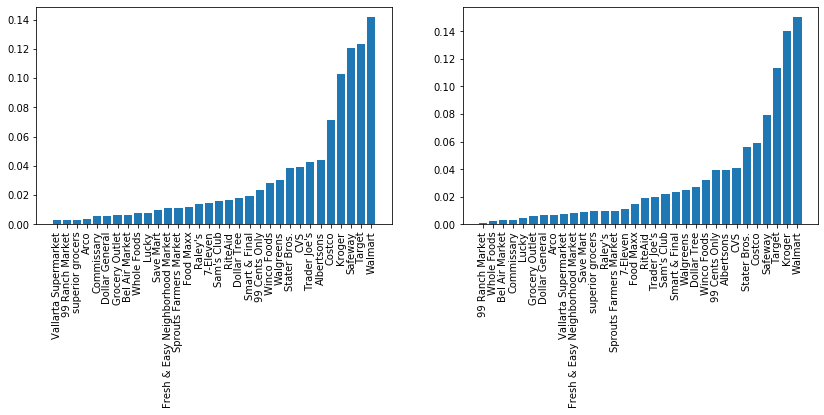

```python
fig, (ax1, ax2) = plt.subplots(nrows=1, ncols=2, figsize = (14, 4))

ax1.bar(
    x = actual.index,
    height = proportions
)
ax1.xaxis.set_tick_params(rotation=90)

ax2.bar(x = list(sorted_probs.keys()), height = list(sorted_probs.values()))
ax2.xaxis.set_tick_params(rotation=90);
```

### 4. Among Dollar General shoppers, which shopper group(s) are most likely to visit, and how do they look different than other shopper group(s)?

Dollar General is retail code 9.

```python
dg_clients = X_test[y_test == 9]
```

```python
dg_preds = rfc.predict_proba(dg_clients)

temp_dict = {name:prob for name, prob in zip(retailer_codes.values(), dg_preds.mean(axis = 0))}
sorted_dg_probs = {k:v for k, v in sorted(temp_dict.items(), key = lambda x: x[1])}
```

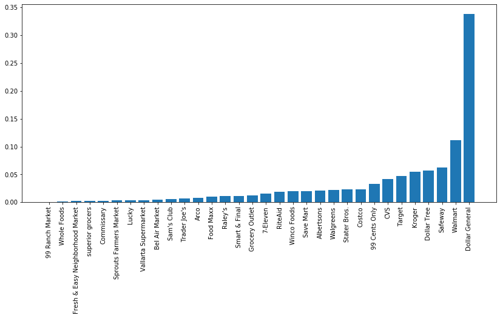

```python
fig, (ax1) = plt.subplots(nrows=1, ncols=1, figsize = (14, 6))

ax1.bar(x = list(sorted_dg_probs.keys()), height = list(sorted_dg_probs.values()))
ax1.xaxis.set_tick_params(rotation=90);
```

### 5. How would Safeway shoppers and/or other retailers be impacted if Safeway were to close their stores?

Safeway is code 18.

```python
sf_clients = X_test[y_test == 18]
```

```python
sf_probs = rfc.predict_proba(sf_clients)
```

```python
temp_dict = {name:prob for name, prob in zip(retailer_codes.values(), sf_probs.mean(axis = 0))}
sorted_sf_probs = {k:v for k, v in sorted(temp_dict.items(), key = lambda x: x[1])}
```

[figure not shown]

```python
fig, (ax1) = plt.subplots(nrows=1, ncols=1, figsize = (14, 5))

ax1.bar(x = list(sorted_sf_probs.keys()), height = list(sorted_dg_probs.values()))
ax1.xaxis.set_tick_params(rotation=90);
```

## General observations and caveats

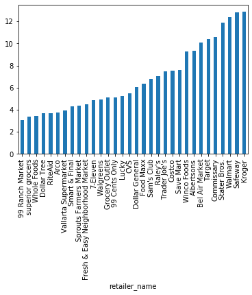

```python
user_counts = data.groupby(["retailer_name", "user_id"]).user_id.count()
user_counts.name = 'counts'
user_counts.reset_index().groupby("retailer_name").counts.mean().sort_values().plot(kind = 'bar')
```

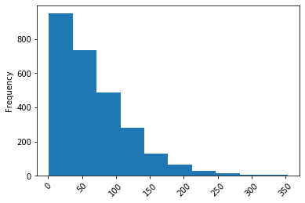

```python
data.groupby('user_id').basket_id.count().plot(kind = 'hist')
plt.xticks(rotation = 45);
```

```python
precision_score(
    y_test,
    pred,
    average = 'weighted',
    sample_weight = compute_sample_weight(
        'balanced',
        y_test
    )
)
```

```
0.6853208194054791
```

```python
accuracy_score(y_test, pred)
```

```
0.62613136471659
```

```python
recall_score(
    y_test,
    pred,
    average = 'weighted',
    sample_weight = compute_sample_weight(
        'balanced',
        y_test
    )
)
```

```
0.5270877539913476
```

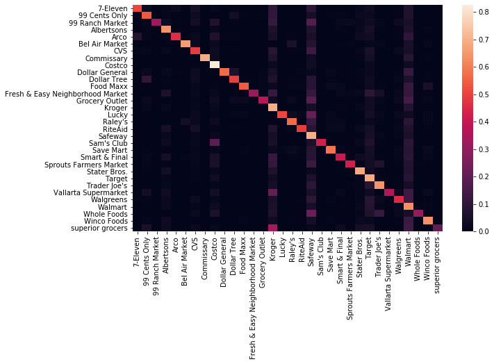

```python
f, ax = plt.subplots(figsize=(10, 6))
ax = sns.heatmap(data = confusion_matrix(y_test, pred, sample_weight = compute_sample_weight( 'balanced', y_test),normalize = 'true'),xticklabels=list(retailer_codes.values()),yticklabels=list(retailer_codes.values()),);
```

## Last thoughts; Questions?

For next steps, things I would attempt are:

1. Dealing with the imbalanced classes issue using one of the aforementioned methods.
2. Re-evaluate my data handling to make sure there is not data leakage or misuse of a class, and double check that I am not spuriously removing some important feature.
3. Check for multicolinearity if a model requires it, and remove sets of features with excessive collinearity (this is another reason why RFC is so useful for preliminary investigations).
4. Make use of a validation set and not simply a test set.
5. Use XGBoost, Catboost, and a neural network to observer performance differences.
6. Choose the apparent winner and optimize that model with a randomized, possibly Bayesian, paramter search.
7. Consider how best to deploy the final model and its requisite end-to-end infrastructure, ie:
   - Do we need to use distributed systems to process data and train the model?
   - Do we need to write some kind of API to receive inputs and return predictions in streams or batches? Or can we simply dump the output somewhere?
   - Does this warrant automated hyperparameter searches on a recurring basis, as well as automating retraining and testing of the model?